# Lecture 1: Introduction to Survival Analysis

STA310 Survival Analysis · Collett Chapter 1

2026-10-06

## Today

1. What is survival analysis?
2. Examples from medicine
3. Censoring
4. Time scales and the independence assumption
5. Describing survival: $S(t)$, $h(t)$, $H(t)$
6. How they relate, and summary measures
7. Roadmap for the course

**Learning goals**

After today you can

- define time-to-event data and explain why censoring needs special methods
- set up survival data in R with `Surv()`
- interpret and relate the survivor, hazard and cumulative hazard functions

# What is survival analysis?

## Time-to-event data

**Survival analysis** = methods for the time from a well-defined *origin* until a well-defined *event*.

| Origin | Event | Field |
| --- | --- | --- |
| Diagnosis of cancer | Death | Oncology |
| Surgery / transplantation | Graft failure | Transplantation |
| Start of treatment | Relapse | Haematology |
| Insertion of an IUD | Discontinuation | Contraception |
| Hospital discharge | Readmission | Health services |
| Start of follow-up | First myocardial infarction | Cardiology |

The event need not be death, and it need not be bad. “Survival” is a generic word (time to recovery, to pregnancy, to discharge).

## Three things must be defined

1. **Time origin**: when does the clock start? (diagnosis, randomisation, surgery)
2. **Event**: what exactly counts? (all-cause death, relapse, …)
3. **Time scale**: how is time measured? (usually time since origin; sometimes age)

**Ambiguous definitions give meaningless results**

“Time from diagnosis” vs “time from start of treatment” can differ by months and change conclusions. Randomisation is the natural origin in a trial since groups are comparable at that point.

## Example 1: IUD discontinuation

Time (weeks) until 18 women discontinued use of an intrauterine device (Collett, Example 1.1).

```r
iud |> t()
```

```
       [,1] [,2] [,3] [,4] [,5] [,6] [,7] [,8] [,9] [,10] [,11] [,12] [,13]
time     10   13   18   19   23   30   36   38   54    56    59    75    93
status    1    0    0    1    0    1    1    0    0     0     1     1     1
       [,14] [,15] [,16] [,17] [,18]
time      97   104   107   107   107
status     1     0     1     0     0
```

`status = 1`: discontinued, `status = 0`: still using the IUD at end of observation (or lost) = **censored**.

## Example 2: Breast cancer and HPA staining

Survival of 45 women with breast cancer, classified by whether the tumour stained positive with the lectin HPA (Collett, Example 1.2).

```r
head(breast, 8)
```

```
     stain time status
1 Negative   23      1
2 Negative   47      1
3 Negative   69      1
4 Negative   70      0
5 Negative   71      0
6 Negative  100      0
7 Negative  101      0
8 Negative  148      1
```

```r
count(breast, stain, status)
```

```
     stain status  n
1 Negative      0  8
2 Negative      1  5
3 Positive      0 11
4 Positive      1 21
```

Question: is staining a prognostic marker?

## Example 3: Multiple myeloma

48 patients with multiple myeloma, with age, sex, blood urea nitrogen, calcium, haemoglobin, plasma cells and protein (Collett, Example 1.3).

```r
head(myeloma, 6)
```

```
  patient time status age sex bun ca   hb pcells protein
1       1   13      1  66   1  25 10 14.6     18       1
2       2   52      0  66   1  13 11 12.0    100       0
3       3    6      1  53   2  15 13 11.4     33       1
4       4   40      1  69   1  10 10 10.2     30       1
5       5   10      1  65   1  20 10 13.2     66       0
6       6    7      0  57   2  12  8  9.9     45       0
```

Question: which baseline variables are associated with survival time?

## Why not “ordinary” statistics?

Survival times are

- **positive** and typically **right-skewed**
- **incomplete**: for some patients we only know that the time exceeds a value

Naive approaches fail:

- Mean of observed times: **underestimates**, as censored times are too short
- Dropping censored patients: biased, discards information, and keeps the early events
- Treat censored as events: also biased downwards
- Logistic regression on “died within 5 years”: needs complete follow-up and discards timing

# Censoring

## Right censoring

We know the patient was event-free until time $c$, but not what happened after.

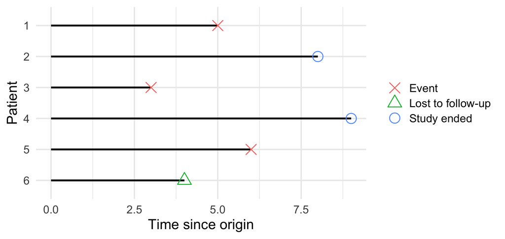

Reasons: study ends, patient withdraws or moves, patient dies of an unrelated cause (see competing risks, Lecture 12–13).

## Other forms of censoring

| Type | What we know | Example |
| --- | --- | --- |
| **Right** | $T > c$ | Alive at end of study |
| **Left** | $T < c$ | HIV-positive at first test, infection time unknown |
| **Interval** | $a < T \le b$ | Recurrence found at a scheduled check-up |

Also: **truncation** (e.g. delayed entry, patients only enter the data if they survive to a certain time).

This course: **right censoring** almost throughout. Interval censoring: overview in Lecture 15 (Chapter 9).

## Types of right censoring

- **Type I**: fixed follow-up time (observe everyone for 5 years)
- **Type II**: stop when a fixed number of events has occurred (animal experiments)
- **Random / administrative censoring**: patients enter at different calendar times and the analysis is made at a common calendar date. **Most common in clinical studies.**

## Study time vs patient time

Patients enter the study at different calendar dates, but each has their own clock.

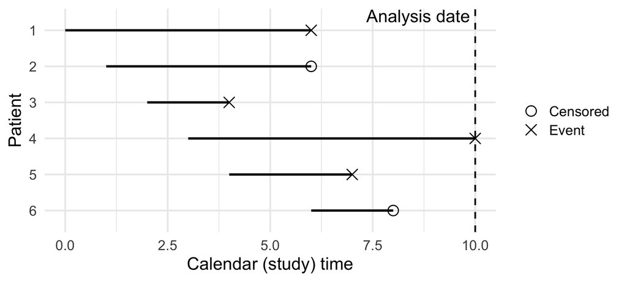

Survival analysis uses **patient time** (time since own origin): shift every line to start at 0.

## The key assumption: independent censoring

Patients who are censored should be representative of those who remain at risk.

Given covariates, censoring must carry **no information** about future event risk.

**Violations**

- Patients withdraw **because they feel worse** (or better)
- Patients are censored when they switch to rescue treatment
- Sickest patients drop out of a trial

The assumption **cannot be tested from the data**. It must be argued from the study design.

(Dependent censoring is treated in Chapter 14, which is outside this course.)

## Data layout and `Surv()` in R

Each patient contributes (at least) a **time** and a **status indicator**.

```r
s <- with(iud, Surv(time, status))
s
```

```
 [1]  10   13+  18+  19   23+  30   36   38+  54+  56+  59   75   93   97  104+
[16] 107  107+ 107+
```

- `Surv()` builds the response; the `+` marks a right-censored time
- Always check the coding of the status variable: `1 = event`, `0 = censored` (also accepts `TRUE/FALSE`, or `1/2` where 2 = event)

## Check the coding

```r
head(lung, 4)     # in the lung data from survival: 1 = censored, 2 = dead
```

```
  inst time status age sex ph.ecog ph.karno pat.karno meal.cal wt.loss
1    3  306      2  74   1       1       90       100     1175      NA
2    3  455      2  68   1       0       90        90     1225      15
3    3 1010      1  56   1       0       90        90       NA      15
4    5  210      2  57   1       1       90        60     1150      11
```

```r
with(lung, Surv(time, status))[1:6]
```

```
[1]  306   455  1010+  210   883  1022+
```

**Tip**

A wrong status coding **silently** gives wrong answers. Always print the first values of `Surv()` and check against the raw data.

## Summary: describing the data

```r
myeloma |>
  summarise(n = n(), events = sum(status), censored = sum(1 - status),
            median_followup_obs = median(time), max_time = max(time))
```

```
   n events censored median_followup_obs max_time
1 48     36       12                14.5       91
```

- **Events** and **censored** counts should always be reported
- Median of the *observed* times is not a median survival time (that comes in Lecture 2)

# Describing survival

## Random variable and distribution

Let $T \ge 0$ be the (random) survival time with density $f(t)$ and distribution function $F(t) = P(T \le t)$.

Three equivalent ways to describe the distribution:

| Function | Definition | Question it answers |
| --- | --- | --- |
| Survivor function $S(t)$ | $P(T > t)$ | What fraction is still event-free at $t$? |
| Hazard function $h(t)$ | instantaneous event rate | How risky is it **right now**, for someone still at risk? |
| Cumulative hazard $H(t)$ | $\int_0^t h(u)\,du$ | How much risk has accumulated until $t$? |

## The survivor function

$$S(t) = P(T > t) = 1 - F(t)$$

- $S(0) = 1$, non-increasing, $S(\infty) = 0$ (when everyone eventually has the event)
- Reading: “probability of surviving beyond $t$”
- **Median survival time**: $t_{50}$ with $S(t_{50}) = 0.5$
- Used to compare groups graphically (Kaplan–Meier curves, Lecture 2)

## The hazard function

$$h(t) = \lim_{\Delta t \to 0} \frac{P(t \le T < t + \Delta t \mid T \ge t)}{\Delta t}$$

- The **instantaneous rate** of the event at $t$, given survival up to $t$
- Not a probability, can exceed 1; unit is “events per unit time”
- $h(t)\Delta t \approx$ probability of the event in the next short interval $\Delta t$

**Intuition**: death rate in the *next week* among those alive today. A car’s hazard of failure is low at first, then increases with age.

## Hazard shapes in medicine

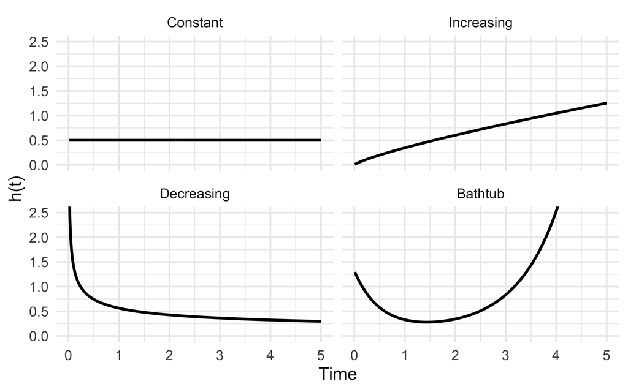

- **Constant**: no ageing, e.g. random events
- **Increasing**: ageing, e.g. patient with untreated chronic disease
- **Decreasing**: early high risk, e.g. after major surgery (perioperative mortality)
- **Bathtub**: neonates, then healthy years, then old age

## Cumulative hazard

$$H(t) = \int_0^t h(u)\,du$$

- Non-decreasing, $H(0) = 0$
- Slope of $H(t)$ is $h(t)$: **easier to estimate** from data than $h(t)$ itself
- Interpretation: expected number of events up to $t$ **if the event could recur** and the patient were kept at risk

## How they relate

$$h(t) = \frac{f(t)}{S(t)} = -\frac{d}{dt}\log S(t), \qquad
H(t) = -\log S(t), \qquad S(t) = \exp\{-H(t)\}$$

Knowing one of $S$, $h$, $H$, $f$ means knowing all.

**Why work with the hazard?**

- It describes the *mechanism* (how risk changes over time)
- Regression models are most naturally built on the hazard: $h(t \mid x) = h_0(t)\, e^{\beta' x}$ (Cox model, Lecture 4)
- Censoring and delayed entry fit naturally

## Example: the exponential distribution

Constant hazard $h(t) = \lambda$. Then

$$H(t) = \lambda t, \qquad S(t) = e^{-\lambda t}, \qquad \text{median} = \frac{\log 2}{\lambda}$$

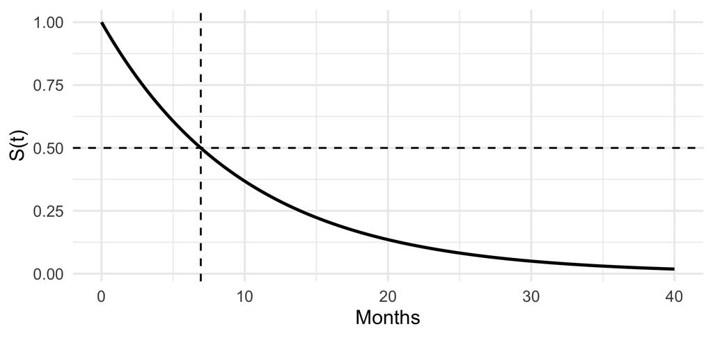

```r
lambda <- 0.1   # events per month
tibble(t = seq(0, 40, 0.1)) |>
  mutate(S = exp(-lambda * t)) |>
  ggplot(aes(t, S)) + geom_line(linewidth = 1.2) +
  geom_hline(yintercept = 0.5, linetype = 2) + geom_vline(xintercept = log(2) / lambda, linetype = 2) +
  labs(x = "Months", y = "S(t)")
```

## Example: the Weibull distribution

$$h(t) = \lambda \gamma t^{\gamma - 1}, \quad S(t) = \exp(-\lambda t^{\gamma})$$

- $\gamma = 1$: exponential. $\gamma > 1$: increasing hazard. $\gamma < 1$: decreasing hazard.

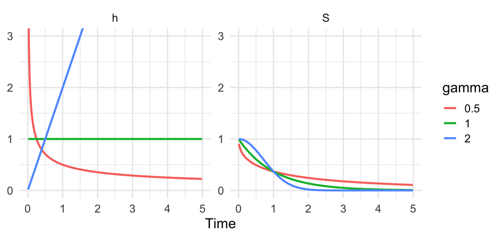

```r
crossing(t = seq(0.01, 5, 0.02), gamma = c(0.5, 1, 2)) |>
  mutate(h = gamma * t^(gamma - 1), S = exp(-t^gamma), gamma = factor(gamma)) |>
  pivot_longer(c(h, S), names_to = "fun", values_to = "value") |>
  ggplot(aes(t, value, colour = gamma)) + geom_line(linewidth = 1.1) +
  facet_wrap(~fun, scales = "free_y") + coord_cartesian(ylim = c(0, 3)) +
  labs(x = "Time", y = NULL)
```

We return to parametric models in Lecture 8 (Chapter 5).

## Hazard vs risk vs probability

**Three different things**

- **Hazard** $h(t)$: rate at $t$ among those still at risk (per time unit)
- **Cumulative incidence** $F(t) = 1 - S(t)$: proportion with the event by $t$
- **Hazard ratio**: ratio of two hazard functions. “Twice the hazard” does **not** mean “twice the probability of dying by 5 years”

Example: if the 1-year survival is 90% in group A and 80% in group B, the risk ratio is 2 for the event, but the ratio of hazards is $\log 0.8 / \log 0.9 \approx 2.12$.

```r
log(0.8) / log(0.9)
```

```
[1] 2.117905
```

## Summary measures of the survival distribution

| Measure | Definition | Comment |
| --- | --- | --- |
| Median survival | $S(t_{50}) = 0.5$ | Most commonly reported; robust to the tail |
| Other percentiles | e.g. $t_{25}$, $t_{75}$ | Often a quartile range |
| $S(t_0)$ | e.g. 5-year survival | Useful when follow-up is adequate |
| Mean | $\int_0^\infty S(t)\,dt$ | Not estimable if the last obs. is censored |
| Restricted mean | $\int_0^{\tau} S(t)\,dt$ | Mean survival up to $\tau$ (Lecture 2) |

# Medical thinking with survival data

## Discussion: what would you do?

A cancer trial reports *“mean follow-up 18 months”*, *“median survival not reached”*, and *“12 of 60 patients censored”*.

1. What might “median survival not reached” mean?
2. Is “mean follow-up” computed from all patients a good measure of follow-up? (Think about censoring. We return to this in Lecture 2.)
3. Which origin and which event would you choose in a trial of adjuvant therapy?

**Pair discussion, 3 minutes.**

## Typical questions answered with survival analysis

| Question | Method | Lecture |
| --- | --- | --- |
| What is the survival curve of this group? | Kaplan–Meier | 2 |
| Do two treatments differ? | Log-rank test | 3 |
| Which factors affect survival, adjusted for others? | Cox regression | 4–7 |
| Does the effect change over time? | Non-proportional hazards | 11 |
| What if a patient can die of several causes? | Competing risks | 12–13 |
| Patients can have repeated events? | Event history | 14 |

## Course roadmap

```
flowchart LR
  A[Concepts<br/>censoring, S, h, H] --> B[Non-parametric<br/>Kaplan-Meier, log-rank]
  B --> C[Cox regression<br/>& model checking]
  C --> D[Parametric<br/>models]
  D --> E[Time-dependent<br/>covariates]
  E --> F[Advanced:<br/>non-PH, competing risks,<br/>recurrent events]
```

[output not shown]

Tools: R with `survival`, `ggsurvfit`, `gtsummary`.

## Take-home messages

- Survival data = time to an event + **censoring**; ignoring censoring biases results
- Define **origin, event and time scale** carefully
- Independent censoring is an assumption that must be argued, not tested
- $S(t)$, $h(t)$ and $H(t)$ are equivalent descriptions: $S(t) = \exp\{-H(t)\}$
- In R: `Surv(time, status)`, and check the coding

**Next lecture**: estimating $S(t)$ and $H(t)$ from data with Kaplan–Meier and Nelson–Aalen.

**Reading**: Collett, Chapter 1.

## Quick quiz

1. A patient is still alive at the end of the study after 40 months. What are the `time` and `status`?
2. If $S(2) = 0.6$, what is $H(2)$?
3. Which of the following is the hazard: the proportion who die in year 2, or the rate of dying at 2 years among those alive at 2 years?
4. A hospital reports average survival time from the recorded times of dead patients only. Direction of the bias?

```r
-log(0.6)
```

```
[1] 0.5108256
```

Answers: (1) time 40, status 0. (2) $-\log 0.6 \approx 0.51$. (3) the second. (4) Underestimated: those who survive longest are still alive, and are excluded.